# EDA Top Tracks

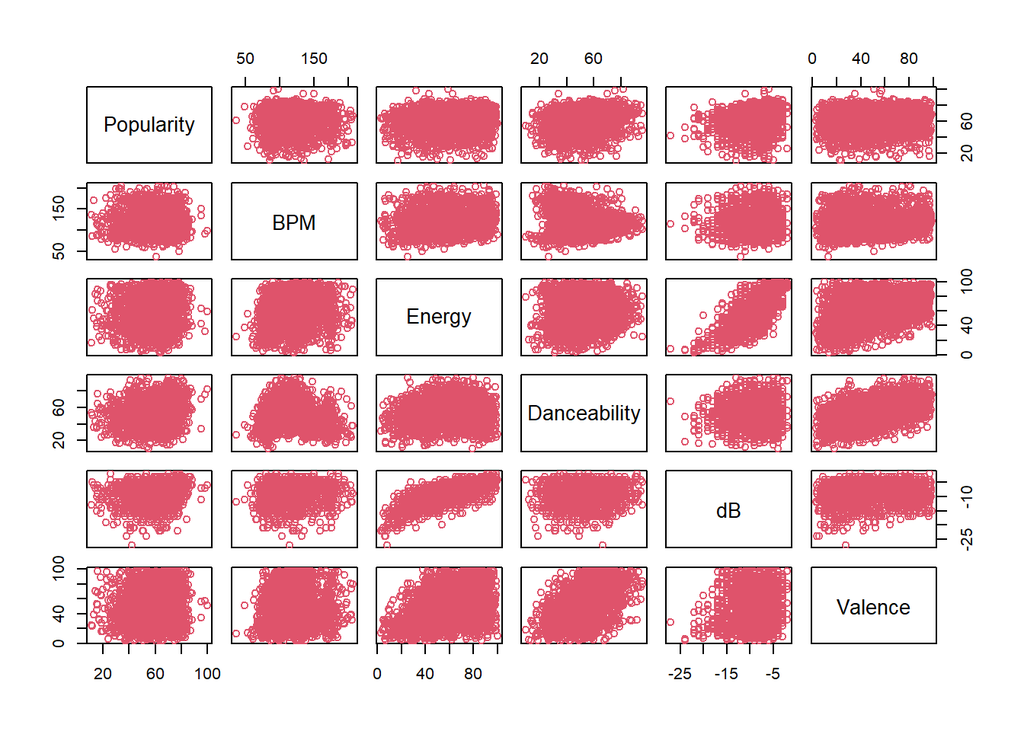

```r
names <- c("Popularity","BPM","Energy","Danceability","dB","Valence")
pairs(Numsongs2[,names], col=2)
```

The scatter plot shows that the population variable pairs are not linearly related. However, the energy and the loudness are positive and linearly related.

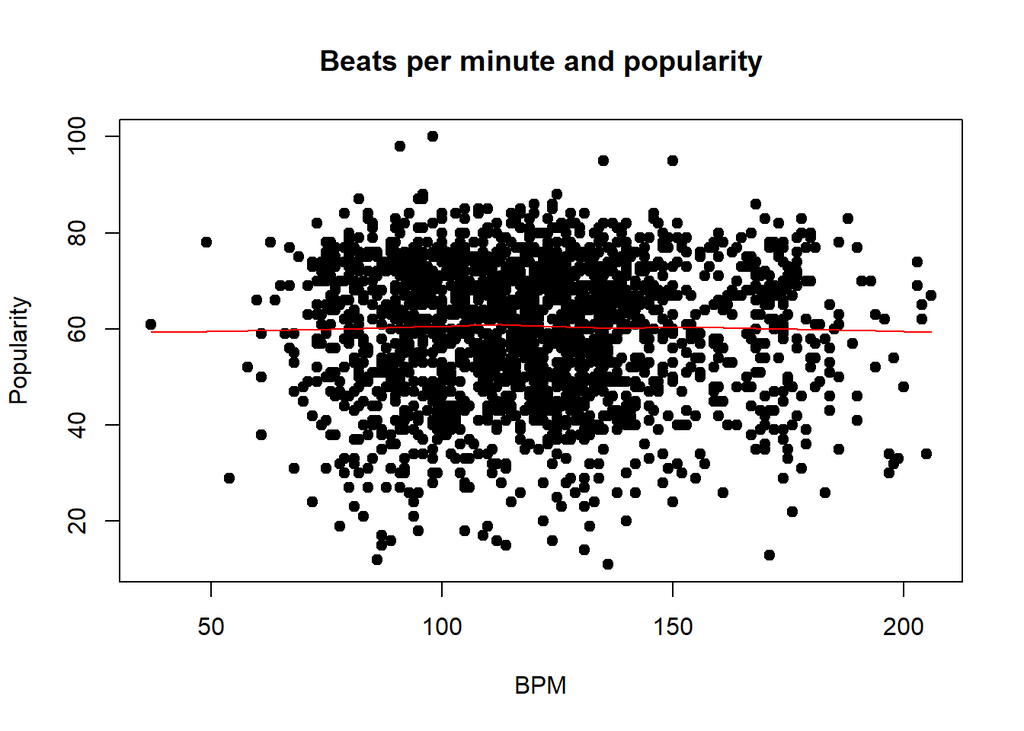

```r
plot(Numsongs2$BPM,Numsongs2$Popularity, main= "Beats per minute and popularity", xlab="BPM", ylab="Popularity", pch=19)
lines(lowess(Numsongs2$BPM,Numsongs2$Popularity), col="red")
```

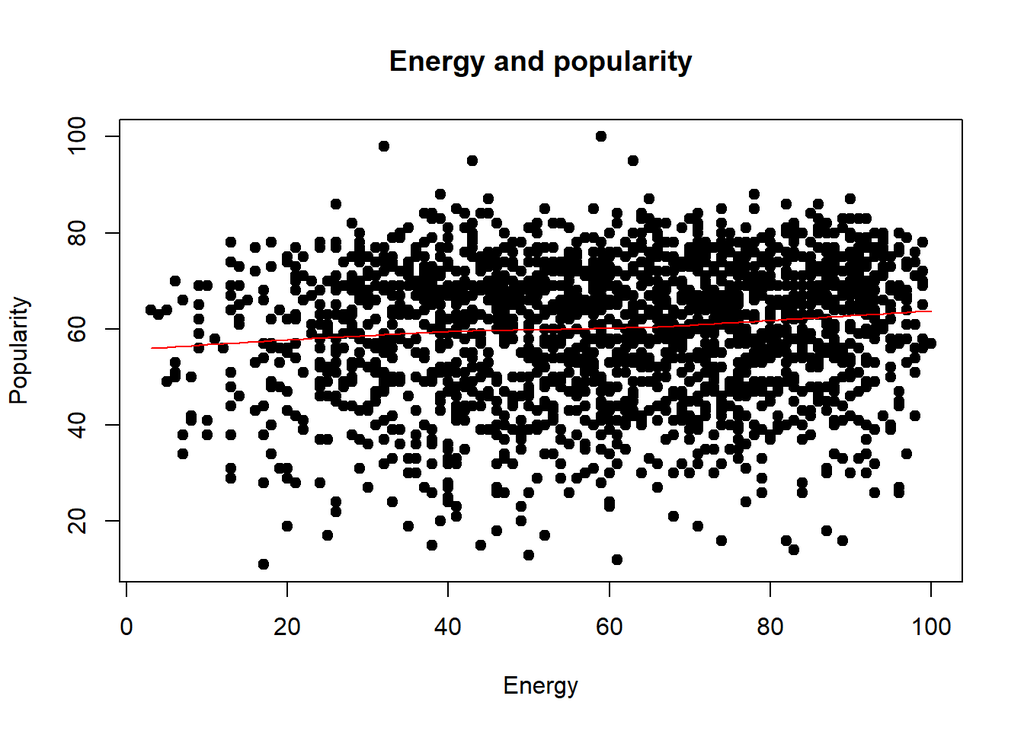

```r
plot(Numsongs2$Energy,Numsongs2$Popularity, main= "Energy and popularity", xlab="Energy", ylab="Popularity", pch=19)
lines(lowess(Numsongs2$Energy,Numsongs2$Popularity), col="red")
```

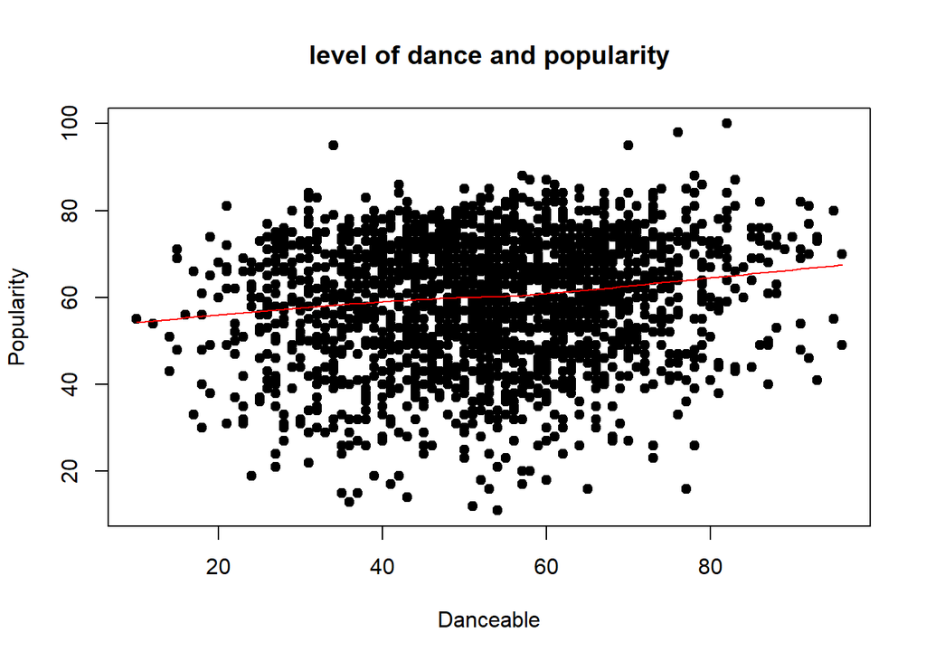

```r
plot(Numsongs2$Danceability,Numsongs2$Popularity, main= "level of dance and popularity", xlab="Danceable", ylab="Popularity", pch=19)
lines(lowess(Numsongs2$Danceability,Numsongs2$Popularity), col="red")
```

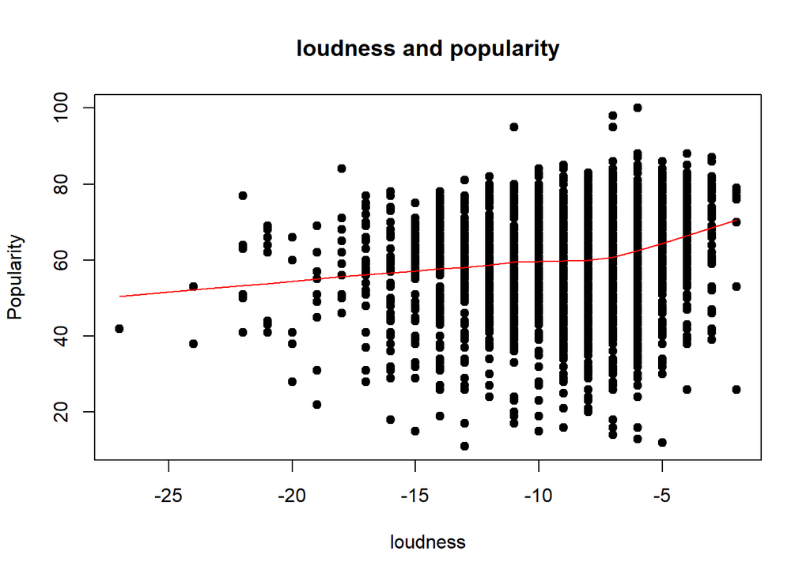

```r
plot(Numsongs2$dB,Numsongs2$Popularity, main= "loudness and popularity", xlab="loudness", ylab="Popularity", pch=19)
lines(lowess(Numsongs2$dB,Numsongs2$Popularity), col="red")
```

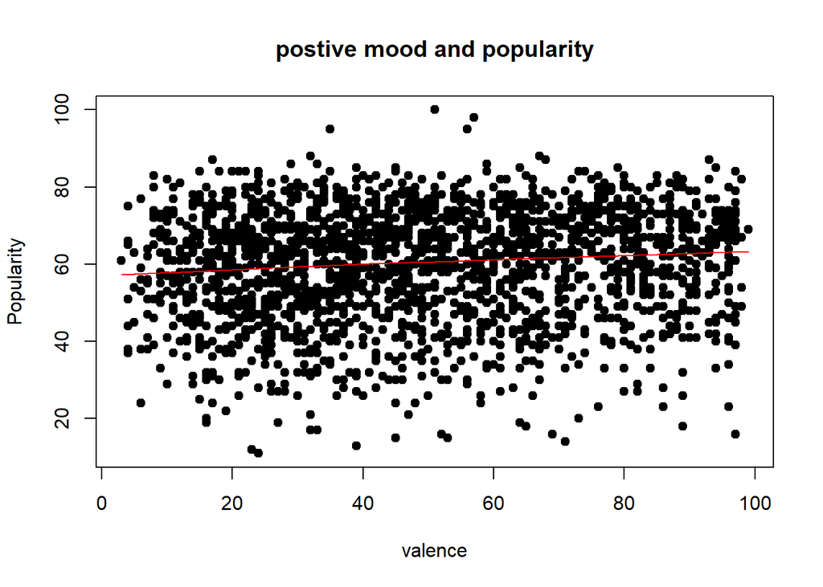

```r
plot(Numsongs2$Valence,Numsongs2$Popularity, main= "postive mood and popularity", xlab="valence", ylab="Popularity", pch=19)
lines(lowess(Numsongs2$Valence,Numsongs2$Popularity), col="red")
```

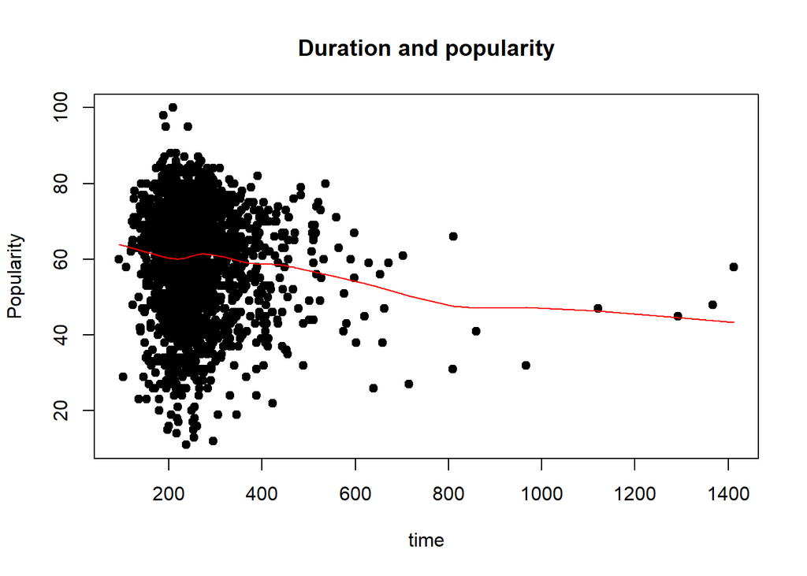

```r
plot(Numsongs2$Duration,Numsongs2$Popularity, main= "Duration and popularity", xlab="time", ylab="Popularity", pch=19)
lines(lowess(Numsongs2$Duration,Numsongs2$Popularity), col="red")
```

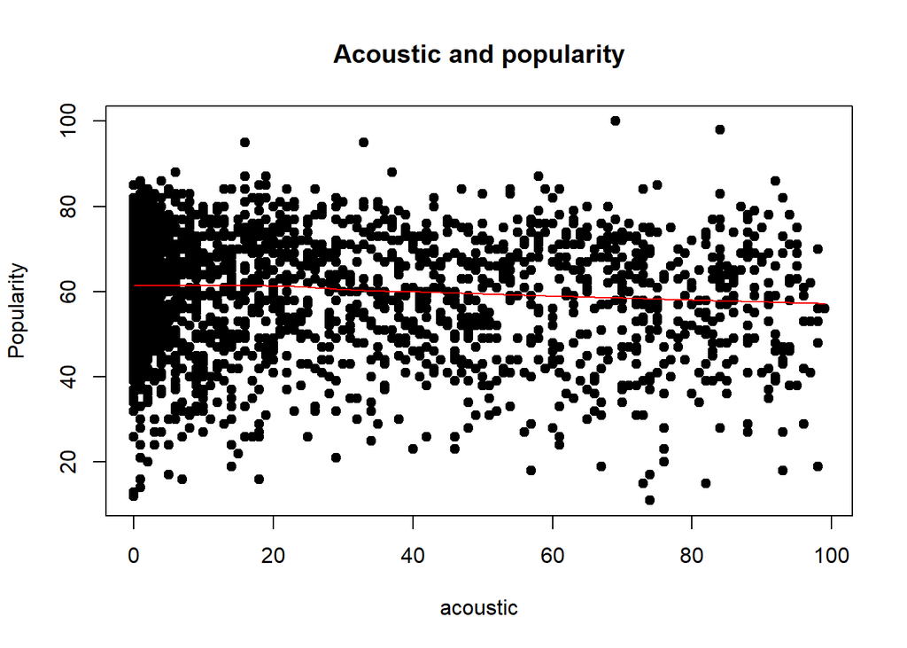

```r
plot(Numsongs2$Acousticness,Numsongs2$Popularity, main= "Acoustic and popularity", xlab="acoustic", ylab="Popularity", pch=19)
lines(lowess(Numsongs2$Acousticness,Numsongs2$Popularity), col="red")
```

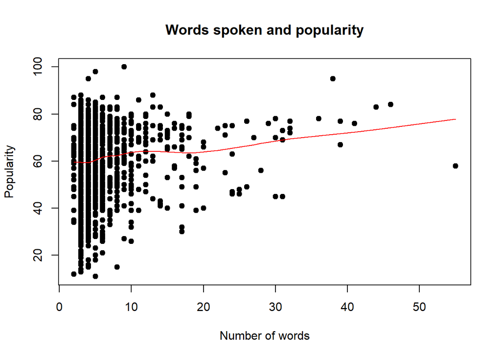

```r
plot(Numsongs2$Speechiness,Numsongs2$Popularity, main= "Words spoken and popularity", xlab="Number of words", ylab="Popularity", pch=19)
lines(lowess(Numsongs2$Speechiness,Numsongs2$Popularity), col="red")
```

Most scatter plots have no relation when popularity is the response variable. However, the duration of a song and the popularity of a song does show a slight negative linear relation. The value for spoken words and the song’s popularity shows a slight positive linear relation.

## Categorical vairable

```r
names(Songs)[names(Songs) == "Top Genre"] <- "TopGenre"
UniqueSongGenre = unique(Songs$TopGenre)# find all unique genres
wordGenre=strsplit(UniqueSongGenre,split = " ")# split each
words=c()
wordsExc=c()
soul=c()
jazz=c()
hip=c()
alternative=c()
dance = c()
rock = c()
pop = c()
for(i in wordGenre) {               # Run for-loop over lists
  for(j in i) {
  # Run for-loop over lists
    words = c(words, j)
}
}
for(i in wordGenre) {
wordsExc = c(wordsExc, trimws(paste(gsub("dutch|arkansas|uk|british|italian|australian|scottish|belgian|canadian|danish|german|alaska|finnish","",i),collapse=" ")))
}
for(i in wordsExc) {
  soul = c(soul,str_replace_all(i,".*soul.*","soul"))
}
for(i in soul) {
  jazz = c(jazz,str_replace_all(i,".*jazz.*","jazz"))
}
for(i in jazz) {
  hip = c(hip,str_replace_all(i,".*hip hop.*","hip hop"))
}
for(i in hip) {
  alternative = c(alternative,str_replace_all(i,".*alternative.*","alternative"))
}
for(i in alternative) {
  dance = c(dance,str_replace_all(i,".*dance.*","dance"))
}

for(i in dance) {
  rock = c(rock,str_replace_all(i,".*rock.*","rock"))
}
for(i in rock) {
  pop = c(pop,str_replace_all(i,".*pop.*","pop"))
}
#unique(pop)
```

```r
#replacing with top genre names based on unique element found above
onlysoul = c()
onlyjazz=c()
onlyhip=c()
onlyalternative=c()
onlyedm=c()
onlydance = c()
onlyindie = c()
onlyfolk = c()
onlyrock = c()
onlyadult= c()
onlycab=c()
other=c()
Abbrev = c()
#replacing with top genre names based on unique element found above
onlyalternative=c()
onlydance = c()
onlyindie = c()
onlyrock = c()
onlyadult= c()
other=c()
Abbrev = c()
for(i in Songs$TopGenre) {
  onlyalternative = c(onlyalternative,str_replace_all(i,".*alternative.*|.*permanent wave.*|.*indie.*","alternative"))
}# replacing anything which contains alternative
for(i in onlyalternative) {
  onlydance = c(onlydance,str_replace_all(i,".*dance.*|.*disco.*|.*electro.*|.*downtempo.*|.*j-core.*|.*diva house.*|.*cyberpunk.*|.*edm|.*gabba.*|.*big room.*|.*trance.*|.*eurodance.*|.*big beat.*|.*happy hardcore.*","dance"))
}# replacing anything which contains dance
for(i in onlydance) {
  onlyrock = c(onlyrock,str_replace_all(i,".*rock.*|.*british invasion.*|.*glam metal.*","rock"))
}# replacing anything which contains rock
for(i in onlyrock) {
  onlyadult = c(onlyadult,str_replace_all(i,".*adult standards.*|.*soul.*|.*jazz.*","adult standards"))
}# replacing anything which contains adult standards
for(i in onlyadult) {
  other = c(other,str_replace_all(i,".*pop.*|.*neo mellow.*","pop"))
}# replacing anything which contains pop
for(i in other) {
  j=str_replace_all(i,"^(?!(alternative|dance|rock|adult standards|pop))","other")
  Abbrev = c(Abbrev,str_replace_all(j,".*other.*","other"))
}# replacing everything else
```

[figure not shown]

```r
pie(table(Songs$TopGenre))
```

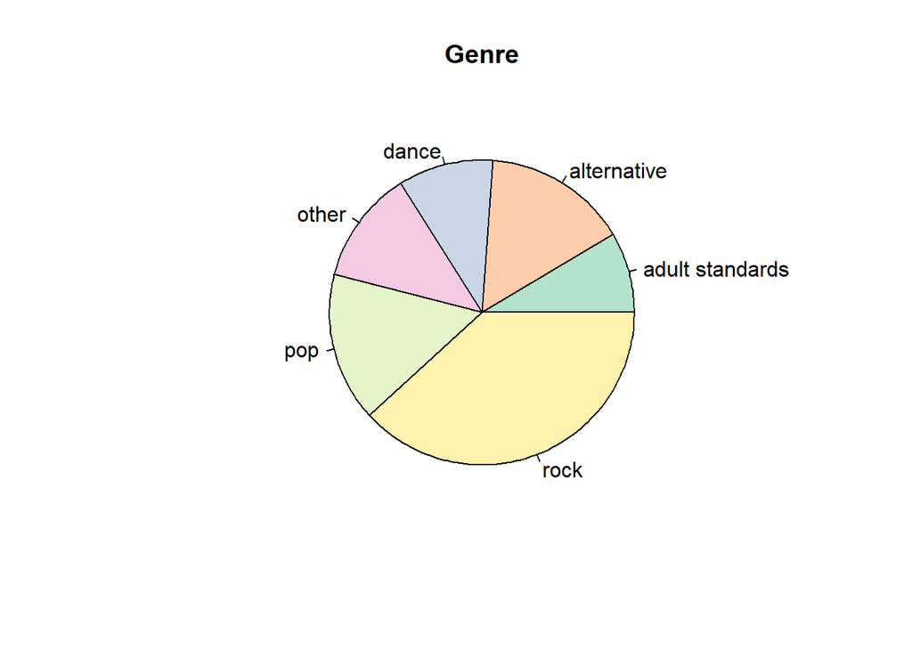

```r
data=as.data.frame(table(Abbrev))

pie(data$Freq,data$Abbrev,main = "Genre",col=brewer.pal(7, "Pastel2"))
```

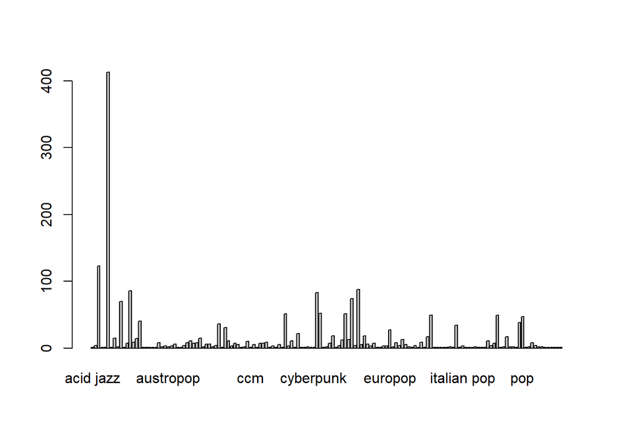

```r
barplot(table(Songs$TopGenre))
```

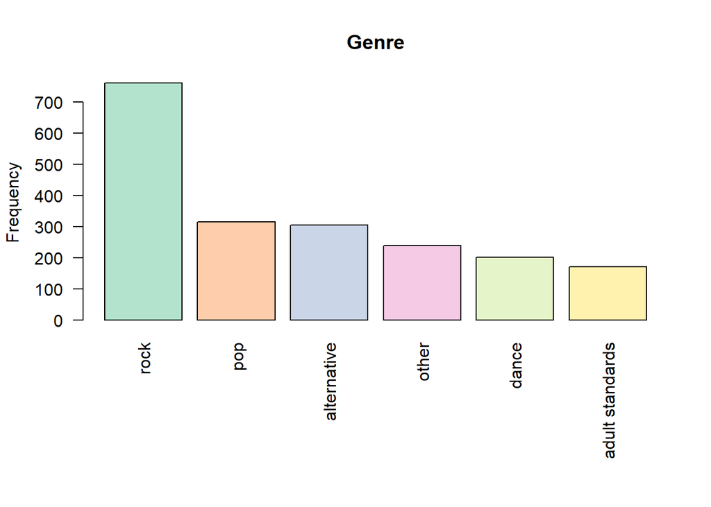

```r
default_margins <- par("mar")
new_margins <- default_margins + c(4, 0, 0, 0)
par(mar = new_margins)
barplot(data[order(data[,2],decreasing=TRUE),
        ][,2],names.arg=data[order(data[,2],decreasing=TRUE),
        ][,1],col=brewer.pal(15, "Pastel2"),
        ylab="Frequency",main="Genre",border="black",las=2)
```

```r
#write Excel file
Songs=data.frame(Songs,Abbrev)
head(Songs)
```

```
##   Index               Title                 Artist      TopGenre Year
## 1  1794           Sacrifice                  Anouk   dutch indie 1998
## 2   774    Hou Vol Hou Vast                   BLØF     dutch pop 2018
## 3   625 Three Days In A Row                  Anouk   dutch indie 2015
## 4   412    Peter Gunn Theme Emerson, Lake & Palmer    album rock 2010
## 5   606     Het Dorp - Live          Wim Sonneveld dutch cabaret 2015
## 6   754         Malle Babbe            Rob De Nijs     dutch pop 2018
##   Beats.Per.Minute..BPM. Energy Danceability Loudness..dB. Liveness Valence
## 1                    136     17           54           -13        9      24
## 2                     86     61           51            -5        8      23
## 3                    171     50           36            -6       16      39
## 4                    131     83           43            -7       92      71
## 5                    114     44           37           -15       67      45
## 6                     87     38           35           -10       12      53
##   Length..Duration. Acousticness Speechiness Popularity      Abbrev
## 1               238           74           5         11 alternative
## 2               295            0           2         12         pop
## 3               254            0           3         13 alternative
## 4               217            1           3         14        rock
## 5               198           82           8         15       other
## 6               253           73           4         15         pop
```

```r
write.csv(Songs,file="Data/songsNewGenre.csv")
```